# DO #1f consolidated v1

Robert Sellers

The Jackson Laboratory

Last knit on: 11 May 2021

# 1 Programming environment

```r
setwd("/Users/seller/Desktop/projects/jax_arsenic_toxicology_analysis")

# env
options(scipen = 999) # suppress sci notation

# contains harmony plate collection class builder
source("scripts/harmony_utils.R")
# various add-on scripts and stats tools
source("scripts/custom_tools.R")
# standrc code that actually works
source('scripts/standrc_evals.R')

library(tidyverse)
library(janitor)
```

```r
library(ggplot2)
library(ggfortify)
library(ggpubr)
library(lme4)
library(lmerTest)
library(sjPlot)
library(nlme)
library(dplyr)
library(standrc)
library(robustbase)
library(scales)
library(tibble)
library(broom)
library(plotly)
library(sqldf)
```

# 2 Data setup

- recontruct initial data fixes to overwrite tempfile

```r
# point to parent data directory
setwd("data/invitro/")
selected_dir <- "./do_focus_merge_2"
# Warning - this currently expects a temp_files data dir
# Set overwrite to TRUE when underlying data dir has been changed
harmony_collection <- harmony_create_collection(dir = selected_dir, overwrite = FALSE)
```

```
##
## Loading existing plate collection from temp_files
```

# 3 Batch corrections

- control group 0 concentration (tbd)
- plate to plate (with lme4 or stan)

# 4 Analytics data construction

```r
feature_subset <- harmony_collection$all_plates %>%
  mutate(fdose=factor(dose)) %>%
  group_by(dir) %>%
  mutate(dir_id = cur_group_id()) %>%
  group_by(individual) %>%
  mutate(individual_id = cur_group_id())
```

# 5 Dose response evaluation

```r
prepare_ed50s_stan <- function(model_, original_data){
  ed50_stan <- ED(model_, respLev=c(50))
  df = data.frame("individual_id" = sort(unique(original_data$individual_id)), "dose" = colMedians(ed50_stan$`50`))
  pred_stan <- predict_harmony(model_, newdata = df)
  df <- df %>%
    rename(
      ed50 = dose
    )
    # calculates the mean across columns in a matrix, based on ((chains-warmup)*iterations)
  df$pred <- apply(pred_stan, 2, function(x) mean(x, na.rm=TRUE))
  df$group <- "stan"
  df$individual_id <- as.character(df$individual_id)
  return (df)
}

prepare_ed50s_drc <- function(model_, original_data){
  # extract ed50 with whatever default calculation
  ed50_drc <- as.data.frame(drc::ED(model_, 50,
                                    interval = 'fls',
                                    display = FALSE,
                                    lref = 0,
                                    uref = 5,
                                    pool=TRUE,
                                    type="absolute")
                            )
  # regex the ugly rownames
  ed50_drc$individual <- str_match(rownames(ed50_drc), ":\\s*(.*?)\\s*:")[,2]
  # for output
  df = data.frame(
    "individual_id" = as.character(ed50_drc$individual),
    "dose" = ed50_drc$Estimate
    )
  # retrieve the response per ed50 estimation with the model
  df$pred <- predict(model_, data.frame(
    dose = ed50_drc$Estimate,
    individual_id = str_match(rownames(ed50_drc), ":\\s*(.*?)\\s*:")[,2]
  ))
  df$group <- "drc"
  df$ed50 <- df$dose
  df$dose <- NULL
  return (df)
}

# batch correction lme4 auto script
batch_correct <- function(formula_,feature, data, r.eff, target_col, debug = FALSE){
  if (debug) browser()
  pheno_raw <- as.numeric(unlist(data[,c(feature)]))
  mn.pheno <- mean(pheno_raw, na.rm=TRUE)
  sd.pheno <- sd(pheno_raw, na.rm=TRUE)
  data$pheno <- (pheno_raw - mn.pheno) / sd.pheno
  fit <- lmer(formula_, data, REML=FALSE)
  random_effects <- ranef(fit)
  effects <- random_effects[[r.eff]]
  batch.ef <- effects[as.character(data[,c(target_col)][[1]]),]
  pheno_sub <- data$pheno - batch.ef
  pheno_adj <- (sd.pheno * pheno_sub) + mn.pheno
  return (pheno_adj)
}

# returns individual id to original value
map_do_to_original <- function(df_new, df_org){
  lookup_df <- df_org[,c('individual','individual_id')]
  return(plyr::join(df_new, distinct(lookup_df), by = "individual_id"))
}

plot_posterior_growth_ci <- function(fit, dat, cred = TRUE, title){
  Y_mean <- rstan::extract(fit, "Y_mean")
  Y_mean_mean <- apply(Y_mean$Y_mean, 2, mean)
  Y_pred <- rstan::extract(fit, "Y_pred")
  Y_pred_mean <- apply(Y_pred$Y_pred, 2, mean)

  if (cred){
    Y_mean_cred <- apply(Y_mean$Y_mean, 2, quantile, c(0.05, 0.95))
    Y_pred_cred <- apply(Y_pred$Y_pred, 2, quantile, c(0.05, 0.95))
    plot(dat$y ~ dat$x, xlab="x", ylab="Y",
       ylim=c(-1, 101), main=title)
    lines(dat$x, Y_mean_mean)
    points(dat$x, Y_pred_mean, pch=19)
    lines(dat$x, Y_mean_cred[1,], col=4)
    lines(dat$x, Y_mean_cred[2,], col=4)
    lines(dat$x, Y_pred_cred[1,], col=2)
    lines(dat$x, Y_pred_cred[2,], col=2)
    legend(x="bottomright", bty="n", lwd=2, lty=c(NA, NA, 1, 1,1),
           legend=c("observation", "prediction", "mean prediction",
                    "90% mean cred. interval", "90% pred. cred. interval"),
           col=c(1,1,1,4,2),  pch=c(1, 19, NA, NA, NA))
  }else{
    plot(dat$y ~ dat$x, xlab="x", ylab="Y",
       ylim=c(-1, 101), main="Non-linear Growth Curve")
    lines(dat$x, Y_mean_mean)
    points(dat$x, Y_pred_mean, pch=19)
    legend(x="bottomright", bty="n", lwd=2, lty=c(NA, NA, 1, 1,1),
           legend=c("observation", "prediction", "mean prediction"),
           col=c(1,1,1,4,2),  pch=c(1, 19, NA, NA, NA))
  }
}

build_standrc_object_single <- function(stan_dat, stancode, fit){
  out <- list()
  out$data <- stan_dat
  out$model <- stancode
  out$stan <- fit
  out$fixedpars <- c("slope","lasy","uasy","ed")
  out$pars <- c("pslope", "plasy", "puasy", "ped", "passym")
  out$curves <- list(pars=c(FALSE,FALSE,FALSE,FALSE),
                     J=1,
                     names=NULL
                     )
  out$fixed <- c(NA,NA,NA,NA,0)
  out$fct <- LL.4()
  class(out) <- "standrc"
  return(out)
}

# extracts upper/lower estimates from drc model, single-curve
extract_upper_lower <- function(m_4param){
  est_a <- coef(m_4param)[2]
  est_b <- coef(m_4param)[3]
  if(est_b > est_a){
    return (list("c" = est_a, "d" = est_b))
  }else{return (list("c" = est_b, "d" = est_a))}
}
```

## 5.1 Transformations / batch corrections

```r
f_ <- formula(pheno ~ (1|mouse) + (1|fdose) + (1|dir))

stan_prep_hoescht_dark <- feature_subset
stan_prep_hoescht_dark$response <- feature_subset$infocus_nucleus_hoechst_ser_dark_1px_mean

stan_prep_hoescht_dark$response  <- batch_correct(formula_ = f_, 'response', stan_prep_hoescht_dark, r.eff = 'dir', target_col = 'dir', debug=FALSE)

# running twice -- apply scale
stan_prep_hoescht_dark <- prepare_data_for_stan('response',
                                        stan_prep_hoescht_dark,
                                        scale = TRUE,
                                        log_ = FALSE)

stan_prep_hoescht_dark_avgs_ <- stan_prep_hoescht_dark %>%
  group_by(fdose, dose, individual_id) %>%
  summarise_at(vars(response), funs(mean(., na.rm=TRUE)))
# consider moving this above
# stan_prep_hoescht_dark <- arrange(stan_prep_hoescht_dark, dose)
```

## 5.2 DRC initial stage + baseline

```r
library(magic) # this is added because of an environment mismatch somewhere
```

```r
options(mc.cores = parallel::detectCores())
m.drc <- drc::drm(response ~ dose,
  data = stan_prep_hoescht_dark,
  separate = TRUE, # make true if needing quick results
  curveid = individual_id,
  type = 'continuous',
  fct = drc::LL.4()
  )

m.drc.single <- drc::drm(response ~ dose,
  data = stan_prep_hoescht_dark,
  type = 'continuous',
  fct = drc::LL.4())

ed50.drc <- prepare_ed50s_drc(m.drc, stan_prep_hoescht_dark)
```

[output not shown]

[output cut: 42 more lines]

[output not shown]

## 5.3 StanDRC

### 5.3.1 Prior estimation

```r
estimates <- extract_upper_lower(m.drc.single)

indv_slope_estimate<- stan_prep_hoescht_dark %>%
  group_by(individual_id) %>%
  nest() %>%
  mutate(model = map(data, ~ lm(response ~ 1 + dose, data = .x) %>% tidy)) %>%
  unnest(model) %>%
  filter(term == 'dose')
```

### 5.3.2 Model generation + priors

- fit the population dose-response curve. Take the averaged response across 4x replicates at each dose for each mouse (1 value per mouse per dose) and fit a single curve. This will yield one ED50 for the measured outcome, plus confidence and prediction intervals. This is a useful way to determine if a trait is going to give good DR behavior and to get a ball park (prior) for the individual fits.
- individual fits. Reduce data to just one mouse. That is 4x reps at each dose. Fit the DR curve, estimate the ED50. Use flat priors. Repeat for all mice. This step will give us per-mouse estimates of ED50 but they will be unstable due to small number of reps.
- fit curve to each mouse but using informative priors. Two ways to do this – hierarchical model in Stan. Could be a computational issue, but best solution. Alternative is repeat individual fits but use strong priors based on the population level fit.

```r
# single aggregate fits for single drc
m.stan.single <- standrm_harmony(
  formula=response ~ dose,
  data=stan_prep_hoescht_dark_avgs_,
  fct = LL.4(),
  iter = 6000)
```

```
## Trying to compile a simple C file
```

[output not shown]

```r
# individual fits on each replicate
# no flat / default priors
m.stan.all.baseline <- standrm_harmony(
  formula = response ~ dose,
  data = stan_prep_hoescht_dark,
  fct = LL.4(), # slope, lower limit, upper limit, ed50
  curveid = b + e ~ individual_id,
  iter = 6000
  )
```

```
## Trying to compile a simple C file
```

[output not shown]

```r
# experimental / in-progress model
m.stan.all.informed <- standrm_harmony(
  formula = response ~ dose,
  data = stan_prep_hoescht_dark,
  fct = LL.4(), # slope, lower limit, upper limit, ed50
  curveid = b + e ~ individual_id,
  standrc_priors(
   b = paste0("normal(pb,",sd(indv_slope_estimate$estimate),")"),
   e = "normal(pe, 1)",
   pb = indv_slope_estimate$estimate,
   pc = as.numeric(estimates$c),
   pd = as.numeric(estimates$d)),
  random = b + c + d ~ dir_id,
  iter = 6000
  )
```

```
## Trying to compile a simple C file
```

[output not shown]

```r
# generate ED50 data for each individual
# functionality currently only for LL.4...
ed50.stan.single <- ED(m.stan.single, respLev=c(50))
ed50.stan.baseline <- prepare_ed50s_stan(m.stan.all.baseline, stan_prep_hoescht_dark)
ed50.stan.informed <- prepare_ed50s_stan(m.stan.all.informed, stan_prep_hoescht_dark)
```

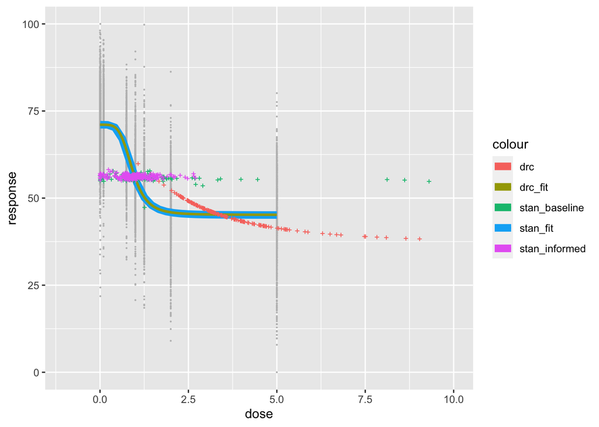

```r
ed50.stan.baseline <- map_do_to_original(ed50.stan.baseline,stan_prep_hoescht_dark)  %>%
  subset(., select = which(!duplicated(names(.))))
ed50.stan.baseline$group <- "stan_baseline"

ed50.stan.informed <- map_do_to_original(ed50.stan.informed,stan_prep_hoescht_dark)  %>%
  subset(., select = which(!duplicated(names(.))))
ed50.stan.informed$group <- "stan_informed"

ed50.drc <- map_do_to_original(ed50.drc,stan_prep_hoescht_dark)  %>%
  subset(., select = which(!duplicated(names(.))))

dual_ed50_df <- rbind(ed50.drc,ed50.stan.baseline, ed50.stan.informed)
# dual_ed50_df <- map_do_to_original(dual_ed50_df,stan_prep_hoescht_dark)

# ggplot_build reverse engineers a ggplot object
plot_stan <- ggplot_build(plot(m.stan.single))
#plot_drc <- ggplot_build(plot(m.drc.single))

#dev.off()

ggplot(data = stan_prep_hoescht_dark,
       aes(x = dose, y = response)) +
  geom_point(col = "grey", size= 0.1 ) +
  geom_line(data = plot_stan$data[[3]], aes(x=x,y=y, col="stan_fit"), size= 3) +
  geom_smooth(method = drm, aes(col = "drc_fit"), method.args = list(fct = LL.4()), se = F) +
  geom_point(data = dual_ed50_df, aes(
    x = ed50,
    y = pred,
    color = group
    ), size = 0.7, shape = 3) +
  xlim(-1,10) #+
```

```r
  # ggrepel::geom_text_repel(data= test, aes(label=individual,x=ed50,y=pred, color=group),size = 2,min.segment.length = 0, segment.color    ="black") +
#      ggrepel::geom_label_repel(data = dual_ed50_df,
#   aes(
#     x=ed50,
#     y=pred,
#     # fill = group,
#     label = individual),
#   fontface = 'bold',
#   color = 'black',
#   size = 1.7,
#   nudge_y = 15,
#   nudge_x = 1,
#   min.segment.length = unit(0, 'lines'),
#   max.overlaps = 20
# ) +
  # scale_colour_manual(
  #   values=c("#0D4F8B", "#0D4F8B","red", "red"),
  #   labels = c("drc L.4","ed50 drc","stan LL.4","ed50 stan"),
  #   guide = guide_legend(
  #     override.aes = list(
  #       linetype = c(1,NA,2,NA)
  #       ))) #+
  ggtitle("Hoescht Dark DRC + Stan fit/ed50 estimation") +
   scale_x_log10() #plots out the dataset with the corresponding 4-parameter log-logit
```

```r
  #xlim(0,10)
  #dose response curves
```

### 5.3.3 Comparative plots

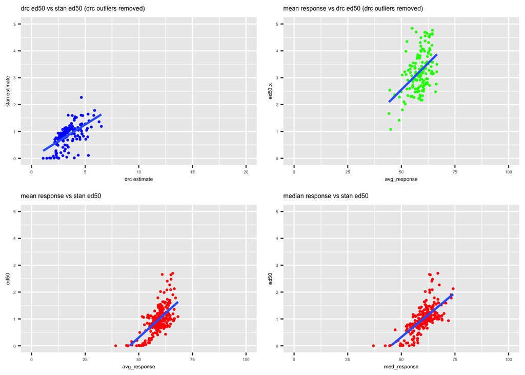

```r
agg_values <- sqldf("select individual,min(response),max(response),median(response) as med_response, avg(response) as avg_response from stan_prep_hoescht_dark group by individual order by avg_response")

long_dual_ed50_df <- base::merge(x = ed50.drc, y = ed50.stan.informed, by = "individual", all = TRUE)

# quick remove outliers
out <- boxplot.stats(long_dual_ed50_df$ed50.x)$out
out_ind <- which(long_dual_ed50_df$ed50.x %in% c(out))
subsubdat <- long_dual_ed50_df[-out_ind, ]

agg_w_stan <- merge(x = agg_values, y = ed50.stan.informed, by = "individual", all = TRUE)

agg_w_drc <- merge(x = agg_values, y = subsubdat, by = "individual", all = TRUE)

p_2models <- ggplot() +
  geom_point(data = subsubdat,aes(x=ed50.x, y=ed50.y),color='blue', size=0.6) +
  geom_smooth(data = subsubdat,aes(x=ed50.x, y=ed50.y),method = "lm", se = FALSE) +
  ggtitle("drc ed50 vs stan ed50 (drc outliers removed)")+
  xlim(0,20)+ ylim(0,5) + ylab("stan estimate") + xlab("drc estimate")+theme(text=element_text(size=5))

p_drc_meanreponse <- ggplot() +
  geom_point(data = agg_w_drc,aes(x=avg_response, y=ed50.x),color='green', size=0.6) +
  geom_smooth(data = agg_w_drc,aes(x=avg_response, y=ed50.x),method = "lm", se = FALSE) +
  ggtitle("mean response vs drc ed50 (drc outliers removed)") +
  xlim(0,100)+ ylim(0,5)+theme(text=element_text(size=5))

p_stan_medianresponse <- ggplot() +
  geom_point(data = agg_w_stan,aes(x=avg_response, y=ed50),color='red', size=0.6) +
  geom_smooth(data = agg_w_stan,aes(x=avg_response, y=ed50),method = "lm", se = FALSE) +
  ggtitle("mean response vs stan ed50") +
  xlim(0,100)+ ylim(0,5)+theme(text=element_text(size=5))

p_stan_meanresponse <- ggplot() +
  geom_point(data = agg_w_stan,aes(x=med_response, y=ed50),color='red', size=0.6) +
  geom_smooth(data = agg_w_stan,aes(x=med_response, y=ed50), method = "lm", se = FALSE) +
  ggtitle("median response vs stan ed50") +
  xlim(0,100)+ ylim(0,5)+theme(text=element_text(size=5))

# plot 4
ggarrange(p_2models, p_drc_meanreponse, p_stan_medianresponse, p_stan_meanresponse, ncol = 2, nrow = 2)
```

# 6 Migration from 01_g

## 6.1 dataset construction

```r
dat <- list(
  "N" = 7498,
  "x" = stan_prep_hoescht_dark$dose,
  "y" = stan_prep_hoescht_dark$response,
  "pb" = 0,
  "pc" = 100,
  "pd" = 0.01,
  "pe" = 0.75,
  "pf" = 0)

# change zero values
invalid <- (dat$x == 0) == TRUE
dat$x[invalid] <- 0.005
# compare these two
#stan_dat <- readRDS("~/Desktop/example.RDS")
#diffobj::diffPrint(target=stan_dat, current=dat)
```

## 6.2 Stan code

```r
stan_ll4 <- "
data {
  int<lower=0> N;
  real y[N];
  real<lower=0> x[N];
  real pb;
  real pc;
  real pd;
  real pe;
}
parameters {
  real<lower=0> sigmasq_y;
  real slope;
  real lasy;
  real uasy;
  real<lower=0> ed;
}
transformed parameters {
  real<lower=0> sigma_y;
  real mu[N];
  sigma_y = sqrt(sigmasq_y);
  for(i in 1:N){
    mu[i] = lasy  + ( uasy - lasy ) / (1 + exp(-exp( slope ) * (log(x[i]/ ed ))))^exp( 0 );
  }
}
model {
  slope ~ normal(pb, 100) ;
  lasy ~ normal(pc, 100) ;
  uasy ~ normal(pd, 100) ;
  ed ~ normal(pe, 100) ;
  sigmasq_y ~ inv_gamma(0.001, 0.001) ;
  y ~ normal(mu, sigma_y);
}
generated quantities {
  real Y_mean[N];
  real Y_pred[N];
  real residuals[N];
  real log_lik[N];
  real pslope;
  real plasy;
  real puasy;
  real ped;
  real passym;
  for (i in 1:N){
    residuals[i] = y[i] - mu[i];
    log_lik[i] = normal_log(y[i], mu[i], sigma_y);
    Y_mean[i] = lasy  + ( uasy - lasy ) / (1 + exp(-exp( slope ) * (log(x[i]/ ed ))))^exp( 0 );
    Y_pred[i] = normal_rng(Y_mean[i], sigma_y);
  }
  pslope  =  slope  ;
  plasy = lasy  ;
  puasy  =  uasy  ;
  ped  =  ed  ;
  passym  =  0  ;
}
"
stan_growth <- "
data {
  int<lower=0> N;
  real<lower=0> x[N];
  real y[N];
}
parameters {
  real alpha;
  real beta;
  real<lower=.5,upper= 1> lambda; // original gamma in the JAGS example
  real<lower=0> tau;
}
transformed parameters {
  real sigma;
  real m[N];
  for (i in 1:N)
    m[i] = alpha - beta * pow(lambda, x[i]);
  sigma = 1 / sqrt(tau);
}
model {
  // priors
  alpha ~ normal(0.0, 1000);
  beta ~ normal(0.0, 1000);
  lambda ~ uniform(.5, 1);
  tau ~ gamma(.0001, .0001);
  // likelihood
  y ~ normal(m, sigma);
}
generated quantities{
  real Y_mean[N];
  real Y_pred[N];
  for(i in 1:N){
    // Posterior parameter distribution of the mean
    Y_mean[i] = alpha - beta * pow(lambda, x[i]);
    // Posterior predictive distribution
    Y_pred[i] = normal_rng(Y_mean[i], sigma);
}
}
"
```

### 6.2.1 Run Stan code

- single growth curve

```r
rstan_options(auto_write = TRUE)
options(mc.cores = parallel::detectCores())
fit_growth <- stan(model_code = stan_growth,
            model_name = "GrowthCurve",
            data = dat)
```

```
## Trying to compile a simple C file
```

[output not shown]

- single ll4 curve

```r
rstan_options(auto_write = TRUE)
options(mc.cores = parallel::detectCores())
fit_ll4 <- rstan::stan(model_code = stan_ll4,
            model_name = "LL4Curve",
            data = dat)
```

```
## Trying to compile a simple C file
```

[output not shown]

### 6.2.2 Plots

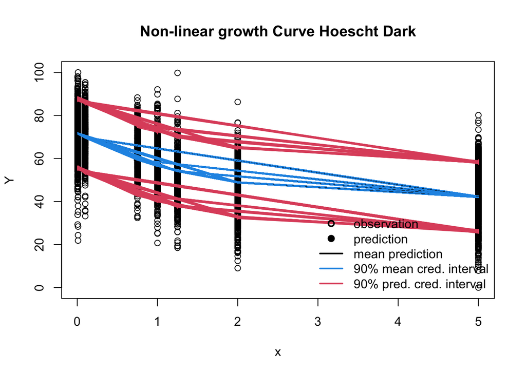

```r
plot_posterior_growth_ci(fit_growth,dat, title="Non-linear growth Curve Hoescht Dark")
```

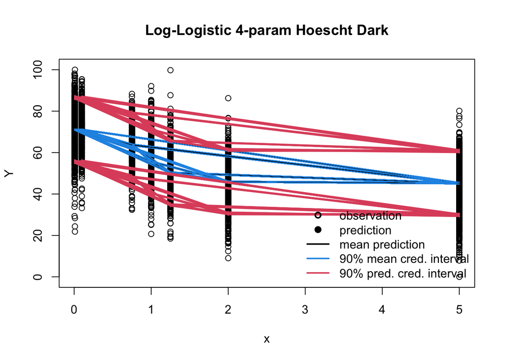

```r
plot_posterior_growth_ci(fit_ll4, dat, title="Log-Logistic 4-param Hoescht Dark")
```

```r
rethinking::precis(fit_growth, pars=c("alpha","beta","lambda", "tau","sigma"))
```

|  | mean | sd | 5.5% | 94.5% | n_eff | Rhat4 |
| --- | --- | --- | --- | --- | --- | --- |
| alpha | 41.21591159 | 0.2310027474 | 40.85068013 | 41.58311903 | 2041.659 | 1.0007795 |
| beta | -30.54432937 | 0.3370571058 | -31.08050313 | -29.99443183 | 2119.252 | 0.9999903 |
| lambda | 0.50107928 | 0.0010603874 | 0.50006202 | 0.50303930 | 3299.320 | 0.9990923 |
| tau | 0.01043322 | 0.0001680968 | 0.01016984 | 0.01069977 | 2431.788 | 1.0015054 |
| sigma | 9.79113472 | 0.0788896052 | 9.66746758 | 9.91614471 | 2436.869 | 1.0014671 |

```r
rethinking::precis(fit_ll4, pars=c("slope","lasy","uasy", "ed","sigmasq_y"))
```

|  | mean | sd | 5.5% | 94.5% | n_eff | Rhat4 |
| --- | --- | --- | --- | --- | --- | --- |
| slope | 1.5190436 | 0.042749907 | 1.4514687 | 1.5866511 | 3686.628 | 0.9999456 |
| lasy | 71.0658268 | 0.170078091 | 70.7999351 | 71.3440511 | 4066.795 | 0.9996944 |
| uasy | 45.2118369 | 0.243311338 | 44.8229551 | 45.5971476 | 3254.612 | 0.9997993 |
| ed | 0.9180046 | 0.009028259 | 0.9033074 | 0.9321551 | 3786.263 | 1.0000930 |
| sigmasq_y | 88.2745344 | 1.437839822 | 85.9640934 | 90.6210046 | 4573.491 | 0.9995021 |